# logistic_regression_modelling_QT

```r
##looking at relationship between numeric variables:
numeric_cols = sapply(data_unique, is.numeric)
data_num_only=data_unique[,numeric_cols]

#data_num_only
```

```r
#Correlation Matrix - default one in R
cor(data_num_only)
```

```
##                        age       fnl_wgt education_num  capital_gain
## age             1.00000000 -0.0764472182    0.03622409  0.0776759387
## fnl_wgt        -0.07644722  1.0000000000   -0.04338837  0.0004285894
## education_num   0.03622409 -0.0433883655    1.00000000  0.1226637280
## capital_gain    0.07767594  0.0004285894    0.12266373  1.0000000000
## capital_loss    0.05774521 -0.0102601352    0.07989194 -0.0316391791
## hours_per_week  0.06851456 -0.0188980370    0.14842219  0.0784075974
##                capital_loss hours_per_week
## age              0.05774521     0.06851456
## fnl_wgt         -0.01026014    -0.01889804
## education_num    0.07989194     0.14842219
## capital_gain    -0.03163918     0.07840760
## capital_loss     1.00000000     0.05422924
## hours_per_week   0.05422924     1.00000000
```

```r
cor_result=rcorr(as.matrix(data_num_only))

cor_result$r
```

```
##                        age       fnl_wgt education_num  capital_gain
## age             1.00000000 -0.0764472182    0.03622409  0.0776759387
## fnl_wgt        -0.07644722  1.0000000000   -0.04338837  0.0004285894
## education_num   0.03622409 -0.0433883655    1.00000000  0.1226637280
## capital_gain    0.07767594  0.0004285894    0.12266373  1.0000000000
## capital_loss    0.05774521 -0.0102601352    0.07989194 -0.0316391791
## hours_per_week  0.06851456 -0.0188980370    0.14842219  0.0784075974
##                capital_loss hours_per_week
## age              0.05774521     0.06851456
## fnl_wgt         -0.01026014    -0.01889804
## education_num    0.07989194     0.14842219
## capital_gain    -0.03163918     0.07840760
## capital_loss     1.00000000     0.05422924
## hours_per_week   0.05422924     1.00000000
```

```r
#look at income with respect to age:
income_by_age =
  data_NA %>%
  group_by(income) %>%
  summarise(mean_age = mean(age, na.rm = TRUE))
```

```r
#flattening correlation plot
flattenCorrMatrix <- function(cormat, pmat) {
  ut <- upper.tri(cormat)
  data.frame(
    row = rownames(cormat)[row(cormat)[ut]],
    column = rownames(cormat)[col(cormat)[ut]],
    cor  =(cormat)[ut],
    p = pmat[ut]
  )
}
```

```r
#flatten correlation matrix:
cor_result_flat = flattenCorrMatrix(cor_result$r, cor_result$P)
head(cor_result_flat)
```

```
##             row        column           cor            p
## 1           age       fnl_wgt -0.0764472182 0.000000e+00
## 2           age education_num  0.0362240878 6.318568e-11
## 3       fnl_wgt education_num -0.0433883655 4.884981e-15
## 4           age  capital_gain  0.0776759387 0.000000e+00
## 5       fnl_wgt  capital_gain  0.0004285894 9.383801e-01
## 6 education_num  capital_gain  0.1226637280 0.000000e+00
```

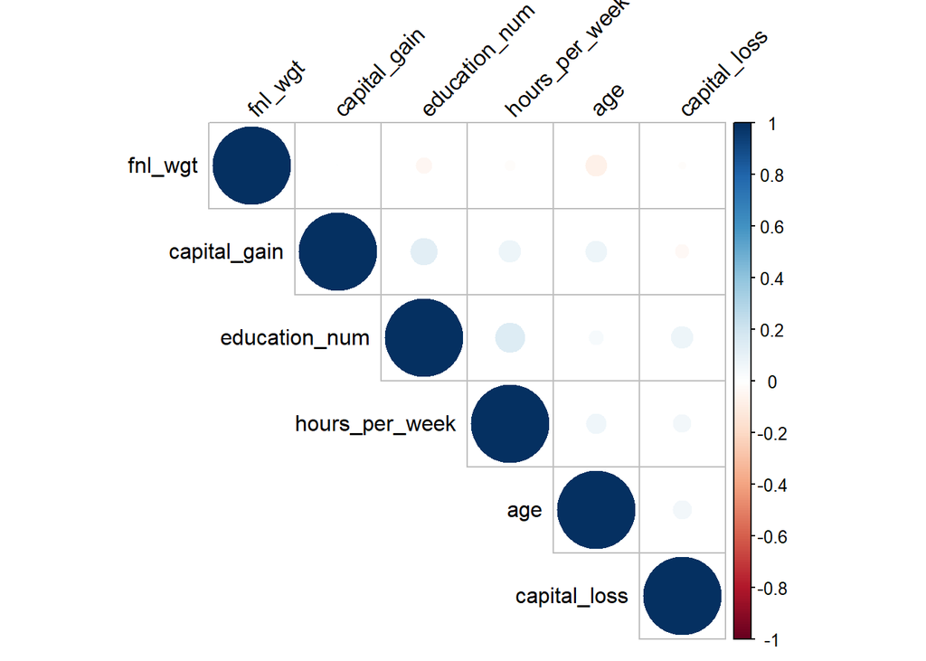

```r
#visualize with a correlogram:
library(corrplot)
corrplot(cor_result$r, type = "upper", order = "hclust", tl.col = "black", tl.srt = 45)
```

#to convert all character columns of dataframe to a factor:

```r
data_factor <- data_unique %>%
  mutate_if(sapply(data_unique, is.character), as.factor)
```

```r
str(data_factor)
```

```
## 'data.frame':    32537 obs. of  15 variables:
##  $ age           : num  39 50 38 53 28 37 49 52 31 42 ...
##  $ workclass     : Factor w/ 8 levels "Federal-gov",..: 7 6 4 4 4 4 4 6 4 4 ...
##  $ fnl_wgt       : num  77516 83311 215646 234721 338409 ...
##  $ education     : Factor w/ 16 levels "10th","11th",..: 10 10 12 2 10 13 7 12 13 10 ...
##  $ education_num : num  13 13 9 7 13 14 5 9 14 13 ...
##  $ marital_status: Factor w/ 7 levels "Divorced","Married-AF-spouse",..: 5 3 1 3 3 3 4 3 5 3 ...
##  $ occupation    : Factor w/ 14 levels "Adm-clerical",..: 1 4 6 6 10 4 8 4 10 4 ...
##  $ relationship  : Factor w/ 6 levels "Husband","Not-in-family",..: 2 1 2 1 6 6 2 1 2 1 ...
##  $ race          : Factor w/ 5 levels "Amer-Indian-Eskimo",..: 5 5 5 3 3 5 3 5 5 5 ...
##  $ sex           : Factor w/ 2 levels "Female","Male": 2 2 2 2 1 1 1 2 1 2 ...
##  $ capital_gain  : num  2174 0 0 0 0 ...
##  $ capital_loss  : num  0 0 0 0 0 0 0 0 0 0 ...
##  $ hours_per_week: num  40 13 40 40 40 40 16 45 50 40 ...
##  $ native_country: Factor w/ 41 levels "Cambodia","Canada",..: 39 39 39 39 5 39 23 39 39 39 ...
##  $ income        : Factor w/ 2 levels "<=50K",">50K": 1 1 1 1 1 1 1 2 2 2 ...
##  - attr(*, "spec")=
##   .. cols(
##   ..   age = col_double(),
##   ..   workclass = col_character(),
##   ..   fnl_wgt = col_double(),
##   ..   education = col_character(),
##   ..   education_num = col_double(),
##   ..   marital_status = col_character(),
##   ..   occupation = col_character(),
##   ..   relationship = col_character(),
##   ..   race = col_character(),
##   ..   sex = col_character(),
##   ..   capital_gain = col_double(),
##   ..   capital_loss = col_double(),
##   ..   hours_per_week = col_double(),
##   ..   native_country = col_character(),
##   ..   income = col_character()
##   .. )
```

```r
#remove rows with missing values:
data_factor <- na.omit(data_factor)
```

```r
dim(data_factor)
```

```
## [1] 30139    15
```

```r
#following this example: https://datascienceplus.com/perform-logistic-regression-in-r/

#use the contrasts() function to check how the categorical variables have been dummified by R:
contrasts(data_factor$sex)
```

```
##        Male
## Female    0
## Male      1
```

```r
contrasts(data_factor$workclass)
```

```
##                  Local-gov Never-worked Private Self-emp-inc Self-emp-not-inc
## Federal-gov              0            0       0            0                0
## Local-gov                1            0       0            0                0
## Never-worked             0            1       0            0                0
## Private                  0            0       1            0                0
## Self-emp-inc             0            0       0            1                0
## Self-emp-not-inc         0            0       0            0                1
## State-gov                0            0       0            0                0
## Without-pay              0            0       0            0                0
##                  State-gov Without-pay
## Federal-gov              0           0
## Local-gov                0           0
## Never-worked             0           0
## Private                  0           0
## Self-emp-inc             0           0
## Self-emp-not-inc         0           0
## State-gov                1           0
## Without-pay              0           1
```

#Splitting the data into training and test sets:

###this version of the dataset omits the NA values: ## Modified from Introduction to Machine Learning with R: Rigorous Mathematical Model by Scott V. Burger p.23

#### split data into 80% for training and 20% for testing

```r
split_size = 0.8
sample_size = floor(split_size * nrow(data_factor))

set.seed(123)
train_indices <- sample(seq_len(nrow(data_factor)), size = sample_size)

train <- data_factor[train_indices, ]
test <- data_factor[-train_indices,]
```

```r
#following this example: https://datascienceplus.com/perform-logistic-regression-in-r/

#train the model, and omit education_num since it's redundant information with education (including it will give NA values)
model <- glm(income ~., data=train[ , !(names(train) %in% c('education_num'))], family=binomial(link='logit'))
summary(model)
```

```
##
## Call:
## glm(formula = income ~ ., family = binomial(link = "logit"),
##     data = train[, !(names(train) %in% c("education_num"))])
##
## Deviance Residuals:
##     Min       1Q   Median       3Q      Max
## -4.4319  -0.5114  -0.1883   0.0000   3.7375
##
## Coefficients:
##                                            Estimate Std. Error z value Pr(>|z|)
## (Intercept)                              -7.303e+00  9.065e-01  -8.057 7.85e-16
## age                                       2.549e-02  1.922e-03  13.261  < 2e-16
## workclassLocal-gov                       -6.917e-01  1.278e-01  -5.412 6.24e-08
## workclassPrivate                         -5.144e-01  1.059e-01  -4.857 1.19e-06
## workclassSelf-emp-inc                    -3.254e-01  1.390e-01  -2.340 0.019263
## workclassSelf-emp-not-inc                -9.556e-01  1.238e-01  -7.717 1.19e-14
## workclassState-gov                       -8.749e-01  1.409e-01  -6.207 5.39e-10
## workclassWithout-pay                     -1.338e+01  2.055e+02  -0.065 0.948092
## fnl_wgt                                   6.995e-07  1.975e-07   3.541 0.000399
## education11th                             3.706e-02  2.343e-01   0.158 0.874319
## education12th                             3.855e-01  3.156e-01   1.222 0.221887
## education1st-4th                         -3.160e-01  5.165e-01  -0.612 0.540659
## education5th-6th                         -6.005e-01  4.083e-01  -1.471 0.141332
## education7th-8th                         -6.971e-01  2.769e-01  -2.517 0.011829
## education9th                             -2.560e-01  2.963e-01  -0.864 0.387614
## educationAssoc-acdm                       1.233e+00  1.970e-01   6.255 3.96e-10
## educationAssoc-voc                        1.223e+00  1.883e-01   6.495 8.28e-11
## educationBachelors                        1.886e+00  1.746e-01  10.803  < 2e-16
## educationDoctorate                        2.909e+00  2.452e-01  11.863  < 2e-16
## educationHS-grad                          7.469e-01  1.696e-01   4.404 1.06e-05
## educationMasters                          2.243e+00  1.873e-01  11.977  < 2e-16
## educationPreschool                       -1.130e+01  1.160e+02  -0.097 0.922396
## educationProf-school                      2.843e+00  2.271e-01  12.518  < 2e-16
## educationSome-college                     1.098e+00  1.722e-01   6.374 1.84e-10
## marital_statusMarried-AF-spouse           2.819e+00  6.174e-01   4.565 4.98e-06
## marital_statusMarried-civ-spouse          2.194e+00  2.989e-01   7.338 2.16e-13
## marital_statusMarried-spouse-absent       1.109e-02  2.787e-01   0.040 0.968254
## marital_statusNever-married              -5.286e-01  9.948e-02  -5.314 1.07e-07
## marital_statusSeparated                  -1.227e-01  1.844e-01  -0.666 0.505648
```

[output cut: 159 more lines]

```
## native_countryThailand
## native_countryTrinadad&Tobago
## native_countryUnited-States
## native_countryVietnam                    **
## native_countryYugoslavia
## ---
## Signif. codes:  0 '***' 0.001 '**' 0.01 '*' 0.05 '.' 0.1 ' ' 1
##
## (Dispersion parameter for binomial family taken to be 1)
##
##     Null deviance: 27120  on 24110  degrees of freedom
## Residual deviance: 15500  on 24015  degrees of freedom
## AIC: 15692
##
## Number of Fisher Scoring iterations: 13
```

### age, workclass, education (Bachelors, Doctorate, Masters, Prof-school), marital_status, occupation, relationship (relationshipWife), sexMale, capital_gain, capital_loss, and hours_per_week have the lowest P values which suggests that these predictors have a strong association with the income class.

```r
#running the anova function to analyze the analysis of variance:
anova(model, test="Chisq")
```

```
## Analysis of Deviance Table
##
## Model: binomial, link: logit
##
## Response: income
##
## Terms added sequentially (first to last)
##
##
##                Df Deviance Resid. Df Resid. Dev  Pr(>Chi)
## NULL                           24110      27120
## age             1   1399.5     24109      25720 < 2.2e-16 ***
## workclass       6    340.2     24103      25380 < 2.2e-16 ***
## fnl_wgt         1      3.2     24102      25377  0.073694 .
## education      15   2930.7     24087      22446 < 2.2e-16 ***
## marital_status  6   4064.7     24081      18382 < 2.2e-16 ***
## occupation     13    616.0     24068      17766 < 2.2e-16 ***
## relationship    5    146.4     24063      17619 < 2.2e-16 ***
## race            4     21.3     24059      17598  0.000281 ***
## sex             1    127.0     24058      17471 < 2.2e-16 ***
## capital_gain    1   1376.7     24057      16094 < 2.2e-16 ***
## capital_loss    1    267.2     24056      15827 < 2.2e-16 ***
## hours_per_week  1    245.0     24055      15582 < 2.2e-16 ***
## native_country 40     81.9     24015      15500  0.000105 ***
## ---
## Signif. codes:  0 '***' 0.001 '**' 0.01 '*' 0.05 '.' 0.1 ' ' 1
```

### marital_status, education, capital_gain, age have the greatest deviance values, and thus

### produces the greatest decrease in residual deviance.

### fnl_wght is not statistically significant.

```r
library(pscl)
pscl::pR2(model)
```

```
## fitting null model for pseudo-r2
```

```
##           llh       llhNull            G2      McFadden          r2ML
## -7.750104e+03 -1.355984e+04  1.161946e+04  4.284515e-01  3.824007e-01
##          r2CU
##  5.662868e-01
```

```r
#using the model to predict on test data set:
fitted.results <- predict(model, newdata=subset(test, select=c(1,2,3,4,6,7,8,9,10,11,12,13,14)), type='response')   #omitting column 5 which is education number

fitted.results
```

```
##            1            6            8           12           26           31
## 1.213548e-01 8.232605e-01 4.084673e-01 3.544113e-01 6.950420e-01 6.922567e-02
##           36           37           43           57           66           71
## 1.127681e-02 7.010175e-03 6.106641e-01 3.755364e-02 2.158973e-01 1.067774e-02
##           76           87           89           90           96           97
## 1.989060e-03 3.649596e-01 1.172249e-02 3.709332e-01 2.081466e-02 9.560370e-01
##           98          105          120          127          141          143
## 4.027562e-01 2.478159e-02 2.141480e-02 8.543664e-03 3.715506e-01 1.842876e-03
##          148          149          151          153          160          167
## 5.936378e-03 5.536737e-01 1.661387e-02 4.821866e-02 3.664037e-02 1.825818e-01
##          170          171          177          178          179          183
## 5.843703e-02 3.810571e-02 6.772263e-03 1.717732e-02 1.182955e-03 5.269835e-02
##          187          194          196          201          204          207
## 1.018733e-01 5.160612e-01 2.032149e-02 2.369089e-01 7.251882e-02 7.619481e-01
##          208          220          223          228          229          238
## 7.965846e-02 1.194479e-02 1.636359e-01 2.299064e-01 7.317268e-03 7.161312e-01
##          240          241          247          255          260          269
## 6.559031e-03 6.266237e-01 3.610140e-01 4.224426e-02 1.830833e-02 6.750286e-02
##          279          282          284          285          289          308
## 8.670771e-03 6.728201e-01 1.816076e-01 3.656214e-03 7.503476e-02 3.312264e-02
##          311          317          320          322          324          341
## 8.386158e-02 4.758767e-01 1.353387e-02 6.159767e-01 1.238593e-02 4.655587e-02
##          349          353          364          367          375          378
## 3.220538e-02 6.245691e-01 5.941706e-01 3.886119e-01 3.350506e-02 3.654172e-02
##          402          405          423          425          430          434
## 6.415233e-03 4.779607e-02 6.362344e-01 4.764126e-03 6.971199e-01 1.293463e-01
##          451          459          461          468          469          473
## 1.848169e-03 2.390607e-01 6.979031e-03 2.631843e-01 9.439781e-01 3.252815e-02
##          482          486          490          498          501          502
## 1.440716e-01 3.870699e-03 9.966645e-01 3.742484e-04 6.099394e-03 2.911375e-01
##          521          523          525          532          536          538
## 9.990914e-01 3.021594e-02 9.059921e-02 1.642767e-02 3.055816e-01 5.780966e-02
##          543          544          549          559          561          563
## 7.983792e-03 2.324961e-02 3.374036e-03 3.696773e-01 1.029333e-01 5.361955e-01
##          566          569          571          589          596          598
## 1.914102e-03 2.082481e-02 8.400145e-03 4.432238e-01 1.092547e-02 9.296554e-01
##          600          602          604          606          607          610
## 9.516930e-02 6.401718e-03 4.027741e-02 1.166379e-02 6.828021e-01 3.076502e-04
##          615          623          629          630          637          638
## 2.431667e-03 2.018774e-04 4.468957e-01 5.238861e-01 3.530351e-02 9.978684e-01
```

[output cut: 1955 more lines]

```
## 2.819944e-01 1.609353e-01 6.408291e-03 1.539819e-01 3.852526e-02 4.733706e-01
##        32348        32352        32356        32357        32360        32361
## 9.998277e-01 7.137786e-03 3.890524e-03 7.461001e-03 1.951612e-02 2.455616e-01
##        32366        32374        32380        32389        32391        32400
## 7.569505e-02 5.857854e-02 6.802436e-01 5.095789e-02 7.829300e-03 9.212214e-03
##        32408        32420        32422        32425        32429        32432
## 7.774211e-03 5.353124e-03 1.635437e-01 1.082258e-01 2.747343e-01 4.802691e-01
##        32437        32439        32445        32448        32451        32468
## 3.720630e-02 8.756595e-01 9.197091e-02 4.222171e-02 3.946958e-01 1.488378e-02
##        32474        32475        32476        32477        32478        32485
## 4.294342e-03 3.074286e-01 1.043130e-02 5.975682e-02 9.275053e-02 1.119198e-03
##        32486        32490        32495        32497        32503        32505
## 2.762149e-02 6.752453e-01 1.000000e+00 8.206143e-03 1.037470e-01 2.281736e-01
##        32510        32515        32517        32525
## 8.229326e-01 9.402454e-01 5.826643e-03 5.700116e-01
```

```r
fitted.results <- ifelse(fitted.results > 0.5, ">50K", "<=50K")           #if the probability is greater than 0.5, y=1, otherwise y=0. Decision boundar is 0.5

misclassification_error <- mean(fitted.results != test$income)
print(paste('Accuracy', 1 - misclassification_error))
```

```
## [1] "Accuracy 0.84406104844061"
```

# Evaluating Logistic Regression Models

### Following tutorial from:

### https://www.r-bloggers.com/2015/08/evaluating-logistic-regression-models/

##Classification Rate

### Examine how well the model does in predicting the target observations on a test set.

### Compare the predicted observations versus actual observations of the target variable.

```r
# use the test set:
fitted.results <- predict(model, newdata=subset(test, select=c(1,2,3,4,6,7,8,9,10,11,12,13,14)), type='response')
fitted.results <- ifelse(fitted.results > 0.5, ">50K", "<=50K")
accuracy <- table(fitted.results, test[,"income"])
sum(diag(accuracy))/sum(accuracy)
```

```
## [1] 0.844061
```

```r
#confusion matrix
fitted.results <- predict(model, newdata=subset(test, select=c(1,2,3,4,6,7,8,9,10,11,12,13,14)), type='response')
fitted.results <- ifelse(fitted.results > 0.5, ">50K", "<=50K")
pred <- as.factor(fitted.results)
confusionMatrix(data=pred, test$income)
```

```
## Confusion Matrix and Statistics
##
##           Reference
## Prediction <=50K >50K
##      <=50K  4222  611
##      >50K    329  866
##
##                Accuracy : 0.8441
##                  95% CI : (0.8347, 0.8531)
##     No Information Rate : 0.755
##     P-Value [Acc > NIR] : < 2.2e-16
##
##                   Kappa : 0.5495
##
##  Mcnemar's Test P-Value : < 2.2e-16
##
##             Sensitivity : 0.9277
##             Specificity : 0.5863
##          Pos Pred Value : 0.8736
##          Neg Pred Value : 0.7247
##              Prevalence : 0.7550
##          Detection Rate : 0.7004
##    Detection Prevalence : 0.8018
##       Balanced Accuracy : 0.7570
##
##        'Positive' Class : <=50K
##
```

#Accuracy = (TP + TN) / (TP + TN + FP + FN) = 0.8441 #Recall (sensitivity) = ratio of total positive / total classified as positive = (TP) /(TP + FN) #sensitivity should be high #Precision = total number of correctly classified positive classes divided by the total number of predicted positive classes = TP/(TP + FP) #precision should be high #Specificity = TN/(TN + FP) = proportion of actual negatives that are correctly identified.

#plot the ROC curve and calculate Area Under the Curve:

#ROC curve plots the True Positive Rate with the False Positive Rate, at different threshold settings. #AUC is the area under the curve, and the better a model is the closer the AUC is to 1, rather than #to 0.5. #values above 0.80 indicate that the model does a good job in discriminating between the two categories which comprise our target variable

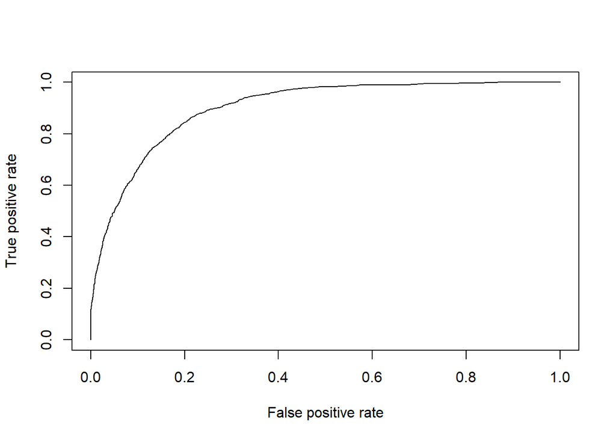

```r
library(ROCR)
p <- predict(model, newdata=subset(test, select=c(1,2,3,4,6,7,8,9,10,11,12,13,14)), type="response")
pr <- prediction(p, test$income)
prf <- performance(pr, measure = "tpr", x.measure = "fpr")
plot(prf)
```

```r
auc <- performance(pr, measure = "auc")
auc <- auc@y.values[[1]]
auc
```

```
## [1] 0.9014257
```

##############################Evaluating the Logistic Regression Model:

####Wald Test

#this test is used to evaluate individual predictors and their statistical significance on the model. #Method: Calculate the ratio of the square of the regression coefficient to the square of the #standard error of the coefficient.

#Null hypothesis: the coefficient of the variable is NOT significantly different from zero. #Alternate hypothesis: the coefficient of the variable IS significantly different from zero.

#If the coefficient of the variable is not significantly different from zero, it will not reject the null hypothesis, #meaning if you take out that variable, it will not significantly affect the model fit.

```r
library(survey)
regTermTest(model, "native_country")
```

```
## Wald test for native_country
##  in glm(formula = income ~ ., family = binomial(link = "logit"),
##     data = train[, !(names(train) %in% c("education_num"))])
## F =  1.616921  on  40  and  24015  df: p= 0.0081029
```

since p= 0.0081029, which is less than 0.05, we reject the null hypothesis that the coefficient of native_country is not significantly different from zero.

```r
regTermTest(model, "fnl_wgt")
```

```
## Wald test for fnl_wgt
##  in glm(formula = income ~ ., family = binomial(link = "logit"),
##     data = train[, !(names(train) %in% c("education_num"))])
## F =  12.53881  on  1  and  24015  df: p= 0.00039934
```

For fnl_wgt, the p= 0.00039934 is less than 0.05, so we reject the null hypothesis that the coefficient of fnl_wght is not significantly different from zero.

```r
##############look at the absolute value of the t-statistic for each predictor:
varImp(model)
```

```
##                                              Overall
## age                                      13.26091087
## workclassLocal-gov                        5.41188952
## workclassPrivate                          4.85696341
## workclassSelf-emp-inc                     2.34039736
## workclassSelf-emp-not-inc                 7.71737111
## workclassState-gov                        6.20734058
## workclassWithout-pay                      0.06510337
## fnl_wgt                                   3.54101766
## education11th                             0.15817434
## education12th                             1.22152461
## education1st-4th                          0.61181631
## education5th-6th                          1.47084817
## education7th-8th                          2.51719757
## education9th                              0.86395199
## educationAssoc-acdm                       6.25541332
## educationAssoc-voc                        6.49539500
## educationBachelors                       10.80330236
## educationDoctorate                       11.86255524
## educationHS-grad                          4.40417049
## educationMasters                         11.97720921
## educationPreschool                        0.09741576
## educationProf-school                     12.51806466
## educationSome-college                     6.37401334
## marital_statusMarried-AF-spouse           4.56546243
## marital_statusMarried-civ-spouse          7.33843165
## marital_statusMarried-spouse-absent       0.03979813
## marital_statusNever-married               5.31363792
## marital_statusSeparated                   0.66562933
## marital_statusWidowed                     0.80670786
## occupationArmed-Forces                    0.55394545
## occupationCraft-repair                    0.51216679
## occupationExec-managerial                 9.32922792
## occupationFarming-fishing                 6.21265591
## occupationHandlers-cleaners               3.84287659
## occupationMachine-op-inspct               2.60246684
## occupationOther-service                   6.21489380
## occupationPriv-house-serv                 1.79649398
## occupationProf-specialty                  5.15966311
## occupationProtective-serv                 3.85542779
```

[output cut: 41 more lines]

```
## native_countryNicaragua                   0.76177049
## native_countryOutlying-US(Guam-USVI-etc)  0.05839241
## native_countryPeru                        0.99019109
## native_countryPhilippines                 0.32081419
## native_countryPoland                      0.52522667
## native_countryPortugal                    0.39718964
## native_countryPuerto-Rico                 0.49268805
## native_countryScotland                    0.45054764
## native_countrySouth                       1.77715593
## native_countryTaiwan                      0.67450659
## native_countryThailand                    1.04789397
## native_countryTrinadad&Tobago             1.31954505
## native_countryUnited-States               0.30418890
## native_countryVietnam                     2.64962911
## native_countryYugoslavia                  0.81885749
```

capital gain, capital loss, age, hours per week, education- Prof School has the highest t-statistic absolute values.

# this version tries to replace the missing values with the most common value of that variable:

```r
View(data_unique)

data_unique %>% count(workclass)
```

```
##          workclass     n
## 1      Federal-gov   960
## 2        Local-gov  2093
## 3     Never-worked     7
## 4          Private 22673
## 5     Self-emp-inc  1116
## 6 Self-emp-not-inc  2540
## 7        State-gov  1298
## 8      Without-pay    14
## 9             <NA>  1836
```

```r
#replicate data:
data1 <-data_unique
```

```r
#replace workclass NA values with "Private"
data1 <- data1 %>%
  mutate(workclass = if_else(is.na(workclass), "Private", workclass))
```

```r
data1 %>% count(workclass)
```

```
##          workclass     n
## 1      Federal-gov   960
## 2        Local-gov  2093
## 3     Never-worked     7
## 4          Private 24509
## 5     Self-emp-inc  1116
## 6 Self-emp-not-inc  2540
## 7        State-gov  1298
## 8      Without-pay    14
```

```r
data1 %>% count(occupation)
```

```
##           occupation    n
## 1       Adm-clerical 3768
## 2       Armed-Forces    9
## 3       Craft-repair 4094
## 4    Exec-managerial 4065
## 5    Farming-fishing  992
## 6  Handlers-cleaners 1369
## 7  Machine-op-inspct 2000
## 8      Other-service 3291
## 9    Priv-house-serv  147
## 10    Prof-specialty 4136
## 11   Protective-serv  649
## 12             Sales 3650
## 13      Tech-support  927
## 14  Transport-moving 1597
## 15              <NA> 1843
```

```r
#replace the missing values in occupation column with "Prof-Specialty" which is the most common value:
data1 <- data1 %>%
  mutate(occupation = if_else(is.na(occupation), "Prof-specialty", occupation))
```

```r
#double check occupation missing values have been replaced in occupation column:
data1 %>% count(occupation)
```

```
##           occupation    n
## 1       Adm-clerical 3768
## 2       Armed-Forces    9
## 3       Craft-repair 4094
## 4    Exec-managerial 4065
## 5    Farming-fishing  992
## 6  Handlers-cleaners 1369
## 7  Machine-op-inspct 2000
## 8      Other-service 3291
## 9    Priv-house-serv  147
## 10    Prof-specialty 5979
## 11   Protective-serv  649
## 12             Sales 3650
## 13      Tech-support  927
## 14  Transport-moving 1597
```

```r
data1 %>% count(native_country)
```

```
##                native_country     n
## 1                    Cambodia    19
## 2                      Canada   121
## 3                       China    75
## 4                    Columbia    59
## 5                        Cuba    95
## 6          Dominican-Republic    70
## 7                     Ecuador    28
## 8                 El-Salvador   106
## 9                     England    90
## 10                     France    29
## 11                    Germany   137
## 12                     Greece    29
## 13                  Guatemala    62
## 14                      Haiti    44
```

[output cut: 28 more lines]

```r
#United-States is the most common value for native country
#so replace NA values with United States:
data1 <- data1 %>%
  mutate(native_country = if_else(is.na(native_country), "United-States", native_country))

data1 %>% count(native_country)
```

```
##                native_country     n
## 1                    Cambodia    19
## 2                      Canada   121
## 3                       China    75
## 4                    Columbia    59
## 5                        Cuba    95
## 6          Dominican-Republic    70
## 7                     Ecuador    28
## 8                 El-Salvador   106
## 9                     England    90
## 10                     France    29
## 11                    Germany   137
## 12                     Greece    29
## 13                  Guatemala    62
## 14                      Haiti    44
```

[output cut: 27 more lines]

```r
str(data1)
```

```
## 'data.frame':    32537 obs. of  15 variables:
##  $ age           : num  39 50 38 53 28 37 49 52 31 42 ...
##  $ workclass     : chr  "State-gov" "Self-emp-not-inc" "Private" "Private" ...
##  $ fnl_wgt       : num  77516 83311 215646 234721 338409 ...
##  $ education     : chr  "Bachelors" "Bachelors" "HS-grad" "11th" ...
##  $ education_num : num  13 13 9 7 13 14 5 9 14 13 ...
##  $ marital_status: chr  "Never-married" "Married-civ-spouse" "Divorced" "Married-civ-spouse" ...
##  $ occupation    : chr  "Adm-clerical" "Exec-managerial" "Handlers-cleaners" "Handlers-cleaners" ...
##  $ relationship  : chr  "Not-in-family" "Husband" "Not-in-family" "Husband" ...
##  $ race          : chr  "White" "White" "White" "Black" ...
##  $ sex           : chr  "Male" "Male" "Male" "Male" ...
##  $ capital_gain  : num  2174 0 0 0 0 ...
##  $ capital_loss  : num  0 0 0 0 0 0 0 0 0 0 ...
##  $ hours_per_week: num  40 13 40 40 40 40 16 45 50 40 ...
##  $ native_country: chr  "United-States" "United-States" "United-States" "United-States" ...
##  $ income        : chr  "<=50K" "<=50K" "<=50K" "<=50K" ...
##  - attr(*, "spec")=
##   .. cols(
##   ..   age = col_double(),
##   ..   workclass = col_character(),
##   ..   fnl_wgt = col_double(),
##   ..   education = col_character(),
##   ..   education_num = col_double(),
##   ..   marital_status = col_character(),
##   ..   occupation = col_character(),
##   ..   relationship = col_character(),
##   ..   race = col_character(),
##   ..   sex = col_character(),
##   ..   capital_gain = col_double(),
##   ..   capital_loss = col_double(),
##   ..   hours_per_week = col_double(),
##   ..   native_country = col_character(),
##   ..   income = col_character()
##   .. )
```

```r
#to convert all character columns of dataframe to a factor:
data1_factor <- data1 %>%
  mutate_if(sapply(data1, is.character), as.factor)

str(data1)
```

```
## 'data.frame':    32537 obs. of  15 variables:
##  $ age           : num  39 50 38 53 28 37 49 52 31 42 ...
##  $ workclass     : chr  "State-gov" "Self-emp-not-inc" "Private" "Private" ...
##  $ fnl_wgt       : num  77516 83311 215646 234721 338409 ...
##  $ education     : chr  "Bachelors" "Bachelors" "HS-grad" "11th" ...
##  $ education_num : num  13 13 9 7 13 14 5 9 14 13 ...
##  $ marital_status: chr  "Never-married" "Married-civ-spouse" "Divorced" "Married-civ-spouse" ...
##  $ occupation    : chr  "Adm-clerical" "Exec-managerial" "Handlers-cleaners" "Handlers-cleaners" ...
##  $ relationship  : chr  "Not-in-family" "Husband" "Not-in-family" "Husband" ...
##  $ race          : chr  "White" "White" "White" "Black" ...
##  $ sex           : chr  "Male" "Male" "Male" "Male" ...
##  $ capital_gain  : num  2174 0 0 0 0 ...
##  $ capital_loss  : num  0 0 0 0 0 0 0 0 0 0 ...
##  $ hours_per_week: num  40 13 40 40 40 40 16 45 50 40 ...
##  $ native_country: chr  "United-States" "United-States" "United-States" "United-States" ...
##  $ income        : chr  "<=50K" "<=50K" "<=50K" "<=50K" ...
##  - attr(*, "spec")=
##   .. cols(
##   ..   age = col_double(),
##   ..   workclass = col_character(),
##   ..   fnl_wgt = col_double(),
##   ..   education = col_character(),
##   ..   education_num = col_double(),
##   ..   marital_status = col_character(),
##   ..   occupation = col_character(),
##   ..   relationship = col_character(),
##   ..   race = col_character(),
##   ..   sex = col_character(),
##   ..   capital_gain = col_double(),
##   ..   capital_loss = col_double(),
##   ..   hours_per_week = col_double(),
##   ..   native_country = col_character(),
##   ..   income = col_character()
##   .. )
```

# Splitting the data into training and test sets:

##version where missing values are imputed with most common values:

```r
split_size = 0.8
sample_size = floor(split_size * nrow(data1_factor))

set.seed(123)
train_indices <- sample(seq_len(nrow(data1_factor)), size = sample_size)

train <- data1_factor[train_indices, ]
test <- data1_factor[-train_indices,]

model <- glm(income ~., data=train[ , !(names(train) %in% c('education_num'))], family=binomial(link='logit'))
summary(model)
```

```
##
## Call:
## glm(formula = income ~ ., family = binomial(link = "logit"),
##     data = train[, !(names(train) %in% c("education_num"))])
##
## Deviance Residuals:
##     Min       1Q   Median       3Q      Max
## -5.0814  -0.5078  -0.1860  -0.0208   3.7370
##
## Coefficients:
##                                            Estimate Std. Error z value Pr(>|z|)
## (Intercept)                              -6.281e+00  8.956e-01  -7.013 2.33e-12
## age                                       2.292e-02  1.812e-03  12.646  < 2e-16
## workclassLocal-gov                       -6.124e-01  1.250e-01  -4.898 9.66e-07
## workclassNever-worked                    -1.322e+01  5.164e+02  -0.026 0.979569
## workclassPrivate                         -5.925e-01  1.044e-01  -5.676 1.38e-08
## workclassSelf-emp-inc                    -3.336e-01  1.369e-01  -2.437 0.014814
## workclassSelf-emp-not-inc                -1.034e+00  1.225e-01  -8.437  < 2e-16
## workclassState-gov                       -8.150e-01  1.388e-01  -5.873 4.27e-09
## workclassWithout-pay                     -1.439e+01  3.792e+02  -0.038 0.969733
## fnl_wgt                                   7.154e-07  1.901e-07   3.764 0.000167
## education11th                             2.210e-01  2.373e-01   0.932 0.351578
## education12th                             5.765e-01  3.000e-01   1.921 0.054687
## education1st-4th                         -2.436e-01  5.040e-01  -0.483 0.628825
## education5th-6th                         -4.444e-01  3.876e-01  -1.147 0.251542
## education7th-8th                         -4.279e-01  2.645e-01  -1.618 0.105716
## education9th                             -1.030e-02  2.857e-01  -0.036 0.971254
## educationAssoc-acdm                       1.574e+00  1.993e-01   7.900 2.80e-15
## educationAssoc-voc                        1.559e+00  1.925e-01   8.097 5.61e-16
## educationBachelors                        2.142e+00  1.790e-01  11.968  < 2e-16
## educationDoctorate                        3.300e+00  2.391e-01  13.801  < 2e-16
## educationHS-grad                          9.222e-01  1.752e-01   5.264 1.41e-07
## educationMasters                          2.517e+00  1.906e-01  13.207  < 2e-16
## educationPreschool                       -1.254e+01  1.840e+02  -0.068 0.945682
## educationProf-school                      3.093e+00  2.227e-01  13.889  < 2e-16
## educationSome-college                     1.305e+00  1.775e-01   7.353 1.94e-13
## marital_statusMarried-AF-spouse           2.739e+00  6.059e-01   4.521 6.17e-06
## marital_statusMarried-civ-spouse          2.419e+00  2.835e-01   8.531  < 2e-16
## marital_statusMarried-spouse-absent      -9.666e-03  2.576e-01  -0.038 0.970064
## marital_statusNever-married              -4.782e-01  9.727e-02  -4.916 8.84e-07
```

[output cut: 161 more lines]

```
## native_countryThailand                   *
## native_countryTrinadad&Tobago
## native_countryUnited-States              .
## native_countryVietnam                    **
## native_countryYugoslavia
## ---
## Signif. codes:  0 '***' 0.001 '**' 0.01 '*' 0.05 '.' 0.1 ' ' 1
##
## (Dispersion parameter for binomial family taken to be 1)
##
##     Null deviance: 28880  on 26028  degrees of freedom
## Residual deviance: 16622  on 25932  degrees of freedom
## AIC: 16816
##
## Number of Fisher Scoring iterations: 14
```

##############Goodness of Fit Evaluation########

### https://www.r-bloggers.com/2015/08/evaluating-logistic-regression-models/

### to test whether the observed difference in model fit is statistically significant, use ANOVA chi-squared test:

```r
anova(model, test="Chisq")
```

```
## Analysis of Deviance Table
##
## Model: binomial, link: logit
##
## Response: income
##
## Terms added sequentially (first to last)
##
##
##                Df Deviance Resid. Df Resid. Dev  Pr(>Chi)
## NULL                           26028      28880
## age             1   1410.3     26027      27470 < 2.2e-16 ***
## workclass       7    449.9     26020      27020 < 2.2e-16 ***
## fnl_wgt         1      3.6     26019      27017  0.059056 .
## education      15   3107.9     26004      23909 < 2.2e-16 ***
## marital_status  6   4250.0     25998      19659 < 2.2e-16 ***
## occupation     13    574.6     25985      19084 < 2.2e-16 ***
## relationship    5    169.5     25980      18915 < 2.2e-16 ***
## race            4     14.0     25976      18901  0.007177 **
## sex             1    129.0     25975      18772 < 2.2e-16 ***
## capital_gain    1   1456.6     25974      17315 < 2.2e-16 ***
## capital_loss    1    265.6     25973      17049 < 2.2e-16 ***
## hours_per_week  1    345.6     25972      16704 < 2.2e-16 ***
## native_country 40     82.2     25932      16622 9.565e-05 ***
## ---
## Signif. codes:  0 '***' 0.001 '**' 0.01 '*' 0.05 '.' 0.1 ' ' 1
```

#fnl_wgt is not significant. #from the anova test, marital status, education, capital_gain, and age have the greatest deviance.

```r
library(pscl)
pscl::pR2(model)   #look at the McFadden value:
```

```
## fitting null model for pseudo-r2
```

```
##           llh       llhNull            G2      McFadden          r2ML
## -8.310794e+03 -1.444019e+04  1.225879e+04  4.244678e-01  3.756016e-01
##          r2CU
##  5.603556e-01
```

#source help: https://www.r-bloggers.com/2015/08/evaluating-logistic-regression-models/:

#McFadden’s R2 = 1−[ln(LM)/ln(L0)], where ln(LM) is the log likelihood value for the fitted model #ln(L0) is the log likelihood for the null model with only an intercept as a predictor # McFadden values range from 0 to 1, and values closer to 0 indicate models have little predictive power.

```r
#using the model to predict on test data set:
fitted.results <- predict(model, newdata=subset(test, select=c(1,2,3,4,6,7,8,9,10,11,12,13,14)), type='response')   #omitting column 5 which is education number

fitted.results
```

```
##           12           14           25           34           35           40
## 3.483322e-01 8.260814e-02 5.764517e-02 2.499422e-01 4.081870e-02 3.521256e-01
##           53           61           65           70           80           82
## 1.663206e-04 6.639622e-01 1.599893e-01 1.267546e-02 2.074638e-02 4.734619e-01
##           83           88           89           90           92           97
## 1.770747e-01 6.702395e-01 1.255127e-02 3.832672e-01 3.572241e-02 9.507090e-01
##          111          118          133          138          139          141
## 4.751074e-02 3.904522e-01 3.821470e-01 3.438508e-01 5.721097e-03 3.734735e-01
##          142          148          154          155          157          158
## 6.577661e-03 5.956588e-03 6.464691e-03 9.742805e-02 3.882337e-02 9.731158e-02
##          159          164          165          174          180          182
## 8.152577e-02 2.173773e-02 5.739594e-01 1.322861e-01 6.690022e-01 3.329462e-02
##          187          193          198          205          207          209
## 9.880913e-02 5.469208e-01 9.727707e-01 1.250489e-02 7.470140e-01 9.918289e-01
##          211          212          220          221          223          228
## 1.908822e-01 2.270903e-01 1.080051e-02 1.484837e-01 1.399691e-01 2.102531e-01
##          240          245          247          261          263          265
## 5.609921e-03 2.060848e-01 3.325819e-01 2.571228e-02 5.437138e-04 1.133982e-01
##          268          286          289          294          297          299
## 4.779266e-01 9.985268e-01 7.939682e-02 1.503141e-02 1.861788e-01 8.027362e-03
##          301          312          317          323          327          337
## 9.240903e-01 9.560001e-01 4.439724e-01 4.759390e-02 2.826476e-03 1.083650e-02
##          339          340          343          348          351          355
## 1.214050e-02 1.176443e-01 7.716069e-01 3.965653e-02 6.202465e-01 6.743482e-01
##          373          376          393          395          418          431
## 2.274437e-01 1.636877e-03 6.402301e-02 4.914201e-03 4.647389e-04 9.688961e-02
##          437          440          446          447          449          452
## 2.369815e-02 4.286083e-01 3.671964e-02 5.567927e-02 1.133117e-01 5.196986e-01
##          460          462          463          466          472          478
## 2.866602e-01 2.453395e-01 5.652011e-01 4.332191e-01 1.134489e-02 3.828436e-03
##          480          489          493          495          496          499
## 3.648768e-03 9.356308e-02 8.441531e-02 1.612927e-02 2.163729e-02 1.495347e-02
##          500          505          514          516          518          521
## 2.906693e-01 4.532582e-02 4.054801e-01 7.976191e-02 6.833664e-03 9.989935e-01
##          524          542          546          547          548          552
## 4.480353e-01 8.980519e-02 6.929761e-03 3.835908e-02 3.900901e-01 4.035259e-03
##          554          557          560          564          565          566
## 2.213281e-01 1.443804e-01 2.019152e-02 4.217455e-03 6.788042e-01 2.215905e-03
##          579          580          585          587          588          590
## 8.966913e-02 1.884435e-01 1.081395e-01 5.923555e-02 1.293666e-03 5.978286e-01
```

[output cut: 2115 more lines]

```
## 7.978490e-01 3.889937e-01 1.351382e-02 9.504227e-01 9.214521e-02 1.074703e-08
##        32303        32311        32322        32326        32335        32336
## 1.608465e-03 6.174368e-01 7.047220e-02 6.001921e-01 4.183673e-02 4.350849e-01
##        32345        32351        32355        32361        32364        32372
## 4.766324e-01 6.672544e-02 3.319686e-01 2.337427e-01 6.063717e-01 1.035196e-02
##        32378        32379        32383        32384        32387        32395
## 7.630244e-01 7.713056e-04 4.057002e-03 1.970336e-02 9.371851e-03 3.918377e-02
##        32396        32398        32411        32432        32437        32439
## 7.328338e-01 1.223972e-01 5.493029e-02 4.940141e-01 3.142209e-02 8.701393e-01
##        32451        32457        32464        32465        32472        32474
## 4.447536e-01 7.517679e-01 5.736872e-01 2.458508e-02 8.070799e-02 4.286488e-03
##        32477        32478        32480        32481        32493        32514
## 5.761457e-02 8.826743e-02 2.846667e-01 2.179167e-01 1.916067e-02 3.470858e-02
##        32517        32519        32525        32530
## 4.875267e-03 2.985601e-01 5.108695e-01 8.734882e-02
```

```r
fitted.results <- ifelse(fitted.results > 0.5, ">50K", "<=50K")           #if the probability is greater than 0.5, income is >50K, otherwise income is =<50K. Decision boundary is 0.5
```

```r
misclassification_error <- mean(fitted.results != test$income)
print(paste('Accuracy', 1 - misclassification_error))
```

```
## [1] "Accuracy 0.855716041794714"
```